# G920_Lab9_Fastovich

#### How much variance do January and July temperatures, annual precipitation, and July sunshine variables explain?

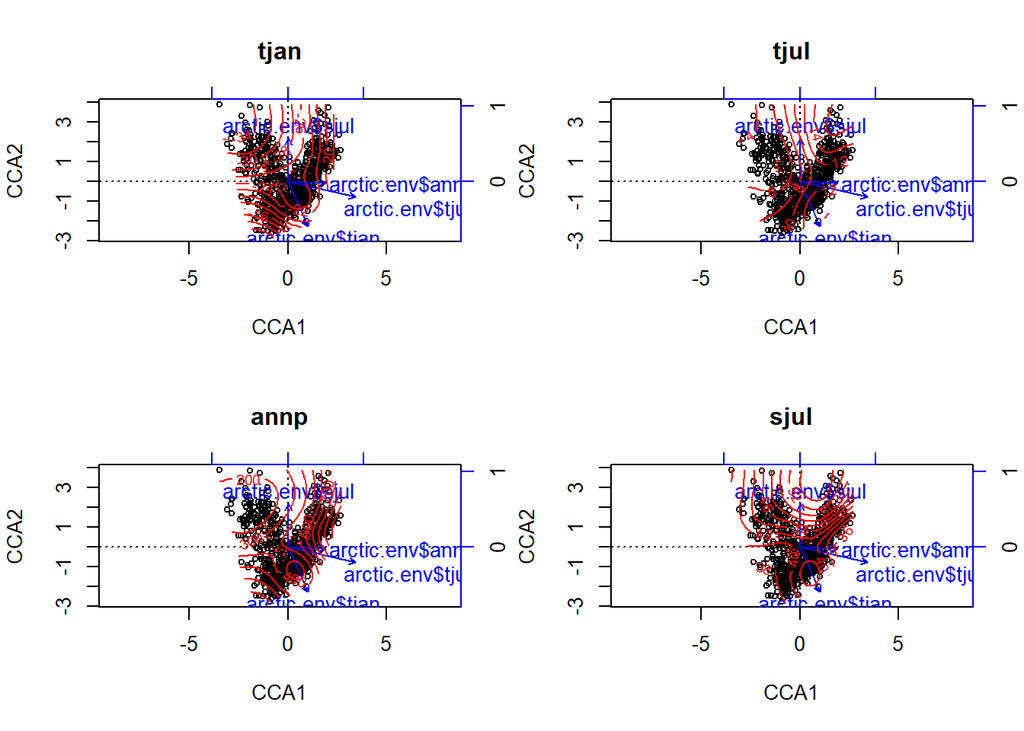

```r
cca.envi <- cca(sqrt(arctic.pollen) ~ arctic.env$tjan + arctic.env$tjul + arctic.env$annp + arctic.env$sjul)
cca.envi
par(mfrow = c(2, 2))
plot(cca.envi)
ordisurf(cca.envi, arctic.env$tjan, add = TRUE, main = "tjan")
plot(cca.envi)
ordisurf(cca.envi, arctic.env$tjul, add = TRUE, main = "tjul")
plot(cca.envi)
ordisurf(cca.envi, arctic.env$annp, add = TRUE, main = "annp")
plot(cca.envi)
ordisurf(cca.envi, arctic.env$sjul, add = TRUE, main = "sjul")
```

- Variance explained by the environmental variables:
- 0.1862256, 0.0698705, 0.0295823, 0.0145867
- annp is loaded entirely on CCA1 and sjul is loaded entirely on CCA2 suggesting that these two variables explain much of the variance in the first and second axes. tjul explains most of the variance in the data and it does so primarily in the first axis but also on the second. tjan and sjul are highly negatively correlated and annp and tjul are highly positively correlated.

### Part 3: Weighted averaging

#### Plot abundances of taxa F.CYPE, F.BBET, F.PPIC,F.PPIN as function of July temeprature.

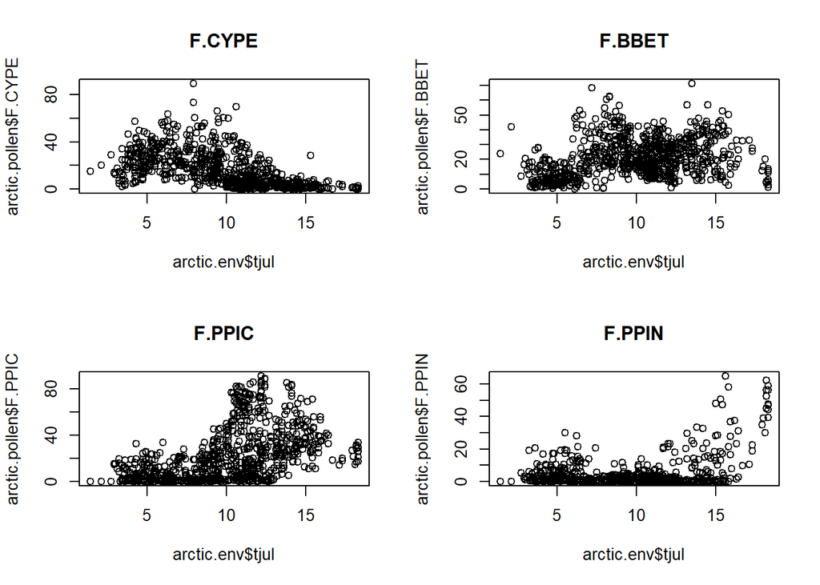

```r
par(mfrow = c(2,2))
plot(y = arctic.pollen$F.CYPE, x = arctic.env$tjul, main = "F.CYPE")
plot(y = arctic.pollen$F.BBET, x = arctic.env$tjul, main = "F.BBET")
plot(y = arctic.pollen$F.PPIC, x = arctic.env$tjul, main = "F.PPIC")
plot(y = arctic.pollen$F.PPIN, x = arctic.env$tjul, main = "F.PPIN")
```